# 1 Objective

In the path to become a data scientist, I would like to showcase this self-executed project. This is a binary unbalanced classification marketing data provided by UC-Irvine. I choose this data because it is realistic, simple and yet tests many concepts and ML algorithms that I have learnt over past two years.

The prediction results are optimized and suited for different business relevant scenarios (jump to this section).

## 1.1 Key technical ideas used:

We make use the following concepts/algorithms

1. Random Forest (RF) ML algorithm for bench marking as it is powerful yet off-the-shelf algorithm (jump to this section).
2. Generalized Linear Model (glm) as it is simplest linear fitting algorithm
3. Cohen’s kappa to measure goodness of prediction, as the binary classification is unbalanced with 1:10 ratio.
4. Gradient Boosting Model (GBM) as it is one of the most powerful ML algorithm
5. Predictors blended with GLM prediction and run with RF and GBM ML algorithm
6. t-test to check if GLM blend produced better results.

# 2 Basic infromation of data

## 2.1 Predictor Variables

UC Irvine Bank Dataset has about 41k observations with 19 predictors variables that are related to following (more details are given in Appendix II - Data Dictionary):

- **Customer information** such as age, marital status, job type, has loan? or a house? and more.
- **Campaign related** attributes such as contact, month, day of the week
- **Social/economic indicator** such as employment variation rate, consumer price index, consumer confidence index and more

## 2.2 Response Variable

The response (also known as target or label) variable is column named “y”. The response variable has two levels “yes” and “no”.

The response “yes” is only 11.3% of data. This means for “no-model”, the random chance of getting “yes” is only 11.3%. This is unbalanced binary classification problem. Hence we will track kappa and balanced accuracy as best indicator for isolating the “yes” customers.

## 2.3 Missing Data

The data at hand does not have any NAs (or missing data). Although original data did have NA which was replaced by “unknown”

# 3 Data Preparation

Based on the description of data Appendix II - Data Dictionary), we remove the duration variable as it will bias the prediction.

We will split the data into three sets as (1) Training Set (2) Test Set (3) Validation set in the ratio of 60:20:20. We shall train the ML algorithm with Training Set, and test it with Test Set. Once we get the final model we will additionally validate with Validation set.

The following code reas the UC-Irivine data from the file and remove “duration” variable

```r
rm(list=ls()) # remove all objects
irvn_org <- read.csv(file="C:\\ds_local\\dataset\\irvine-bank-marketing.txt")
irvn_org$duration <- NULL
#
irvn <-irvn_org
yirvn <- irvn_org[,"y",drop=FALSE]
dim(irvn)
```

```
## [1] 41188    20
```

The following code splits the data into three sets: Training set, Test set and Validation Set

```r
set.seed(12345)
idx <- sample(seq(1,3), size = nrow(irvn_org), replace = TRUE, prob = c(60,20,20))
table(idx)
```

```
## idx
##     1     2     3
## 24903  8121  8164
```

```r
# Defining new sets seperatly for tain set and test set
yirvn_tr <- yirvn[idx==1,]
yirvn_te <- yirvn[idx==2,]
yirvn_vl <- yirvn[idx==3,]
```

The following code converts “month” varibale from the three character month to month-integer, which hints the ML algorithm to use as ordinal variabe.

```r
library(plyr)
idx_month <- as.numeric(mapvalues(irvn_org$month,
                                   from=c("jan","feb","mar","apr","may",
                                          "jun","jul","aug","sep","oct","nov","dec"),
                                     to=c(1:12)))
length(idx_month) # check if it is same as data record count
```

```
## [1] 41188
```

The follwing code check (i) column names, (ii) structure (iii) any NA present (iv) ratio or binary response.

```r
colnames(irvn) # column names
```

```
##  [1] "age"            "job"            "marital"        "education"
##  [5] "default"        "housing"        "loan"           "contact"
##  [9] "month"          "day_of_week"    "campaign"       "pdays"
## [13] "previous"       "poutcome"       "emp.var.rate"   "cons.price.idx"
## [17] "cons.conf.idx"  "euribor3m"      "nr.employed"    "y"
```

```r
str(irvn) # structure
```

```
## 'data.frame':    41188 obs. of  20 variables:
##  $ age           : int  56 57 37 40 56 45 59 41 24 25 ...
##  $ job           : Factor w/ 12 levels "admin.","blue-collar",..: 4 8 8 1 8 8 1 2 10 8 ...
##  $ marital       : Factor w/ 4 levels "divorced","married",..: 2 2 2 2 2 2 2 2 3 3 ...
##  $ education     : Factor w/ 8 levels "basic.4y","basic.6y",..: 1 4 4 2 4 3 6 8 6 4 ...
##  $ default       : Factor w/ 3 levels "no","unknown",..: 1 2 1 1 1 2 1 2 1 1 ...
##  $ housing       : Factor w/ 3 levels "no","unknown",..: 1 1 3 1 1 1 1 1 3 3 ...
##  $ loan          : Factor w/ 3 levels "no","unknown",..: 1 1 1 1 3 1 1 1 1 1 ...
##  $ contact       : Factor w/ 2 levels "cellular","telephone": 2 2 2 2 2 2 2 2 2 2 ...
##  $ month         : Factor w/ 10 levels "apr","aug","dec",..: 7 7 7 7 7 7 7 7 7 7 ...
##  $ day_of_week   : Factor w/ 5 levels "fri","mon","thu",..: 2 2 2 2 2 2 2 2 2 2 ...
##  $ campaign      : int  1 1 1 1 1 1 1 1 1 1 ...
##  $ pdays         : int  999 999 999 999 999 999 999 999 999 999 ...
##  $ previous      : int  0 0 0 0 0 0 0 0 0 0 ...
##  $ poutcome      : Factor w/ 3 levels "failure","nonexistent",..: 2 2 2 2 2 2 2 2 2 2 ...
##  $ emp.var.rate  : num  1.1 1.1 1.1 1.1 1.1 1.1 1.1 1.1 1.1 1.1 ...
##  $ cons.price.idx: num  94 94 94 94 94 ...
##  $ cons.conf.idx : num  -36.4 -36.4 -36.4 -36.4 -36.4 -36.4 -36.4 -36.4 -36.4 -36.4 ...
##  $ euribor3m     : num  4.86 4.86 4.86 4.86 4.86 ...
##  $ nr.employed   : num  5191 5191 5191 5191 5191 ...
##  $ y             : Factor w/ 2 levels "no","yes": 1 1 1 1 1 1 1 1 1 1 ...
```

```r
anyNA(irvn) # Are there any NAs
```

```
## [1] FALSE
```

```r
table(irvn$y)/length(irvn$y)*100 # Frequency (in %) of response
```

```
##
##       no      yes
## 88.73458 11.26542
```

# 4 Benchmarking with RF

After the data is prepared, we choose to run Random Forest (RF) algorithm because it is one of the best ML algorithm and off-the-shelf ML (i.e., no tuning is needed!). We run Random forest with as-is data to get the performance metrics and getting importance of variables. (jump to the code section

## 4.1 Importnce of variables

It is surprising that there are no variables depending strongly on customer’s information. Apart from campaign info – month, all variables relates to socio/economic indicators.

## 4.2 Performance Metrics

Confusion Matrix is powerful representation from which variety of performance metrics can be derived. We will select some metrics that will help in the business case.

Looking at the output of confusion matrix (from Caret package), we note the following: (jump to the code section:

$$\begin{array}
{c|c|c}
n=8121 & \text{Actual:}\; ``No" & \text{Actual:}\; ``Yes" \\[10pt]
\hline\text{Predicted:}\; ``No" & 6978 & 672 \\[10pt]
\hline\text{Predicted:}\;``Yes" & 186 & 285
\end{array}$$

### 4.2.1 Kappa

Kappa or balanced accuracy is the key performance metrics for ML code because we are dealing with unbalanced binary classification problem. Running the RF gives kappa = 0.35 and balance accuracy = 64%

### 4.2.2 Subscription Conversion Rate

We find the “Neg Pred Value” to be related to Subscription Coversion Rate probability which is events that are:
$$\small\text{Subscription Coversion Rate probability}= {\text{Predicted to be "Yes" which are Actually "Yes"}\over{\text{Predicted to be "Yes"}}}$$

$$= {285\over{285+186}} = 60.5\%$$

### 4.2.3 Potential Customer Capture

We also find the Specificity to be related to Potential Customer Capture proability which are events that are:
$$\small\text{Potential Customer Capture probability}= {\text{Predicted to be "Yes" which are Actually "Yes"}\over{\text{Total of Actual "Yes"}}}$$

$$= {285\over{285+672}} = 29.8\%$$

## 4.3 Performance Metrics to Monitor

Reimphasizing the above finding, we will continue to track the following metricsfor various ML algorithms with this Random Forest benchmark

- kappa = 0.35
- balanced accuracy = 64%
- Subscription Conversion Rate (“Neg Pred Value”) = 60.5%
- Potential Customer Capture (specificity) = 29.8%

## 4.4 RF Code Section

Following code is run which gives the results stated in key finding stated above.

```r
set.seed(1234)
#for (ii in 1:10){
irvn_rf <- irvn_org
library(randomForest)
system.time(fit.rf <- randomForest(y~.,data=irvn_rf[idx==1,], importance=TRUE))  # no tuning
```

```
##    user  system elapsed
##  438.06    4.83  486.44
```

```r
# order the important variable with MeanDecreaseAccuracy
fit.rf$importance[order(fit.rf$importance[,c("MeanDecreaseAccuracy"),drop=FALSE], decreasing=TRUE),]
```

```
##                          no           yes MeanDecreaseAccuracy
## month          0.0570143834 -1.664392e-02         0.0487899563
## euribor3m      0.0518862532  8.949426e-03         0.0470905512
## nr.employed    0.0337315269  3.778767e-02         0.0341808185
## emp.var.rate   0.0367476025  2.220513e-03         0.0328865796
## cons.price.idx 0.0367559809 -1.608169e-02         0.0308541944
## cons.conf.idx  0.0253804983 -8.431381e-03         0.0216098896
## job            0.0082771811 -1.502921e-03         0.0071852859
## day_of_week    0.0061577079  3.095380e-03         0.0058137767
## contact        0.0047759912  1.196390e-02         0.0055788459
## age            0.0058155395  1.375329e-03         0.0053201682
## pdays          0.0018745776  3.220220e-02         0.0052610356
## poutcome       0.0035456312  1.143717e-02         0.0044274776
## education      0.0048134562  5.208731e-04         0.0043348176
## previous       0.0032255790 -3.604462e-05         0.0028629739
## campaign       0.0012011843  4.734117e-03         0.0015969311
## marital        0.0014067673 -1.509135e-03         0.0010802635
## default        0.0004916259  2.469071e-03         0.0007135081
## housing        0.0004265548  2.552616e-04         0.0004085574
## loan           0.0001566937 -9.792315e-05         0.0001283191
##                MeanDecreaseGini
## month                 153.81960
## euribor3m             532.06555
## nr.employed           301.77370
## emp.var.rate           97.02326
## cons.price.idx        103.88029
## cons.conf.idx         122.77371
## job                   372.86899
## day_of_week           251.05134
## contact                57.28548
## age                   534.45128
## pdays                 186.66563
## poutcome              151.66524
## education             282.99037
## previous               76.78393
## campaign              259.05564
## marital               132.24321
## default                47.18880
## housing               120.59798
## loan                   87.81618
```

```r
pred_rf_te<-predict(fit.rf, irvn_rf[idx==2,])
library(caret)
length(yirvn_te)
```

```
## [1] 8121
```

```r
print(confusionMatrix(pred_rf_te, yirvn_te))
```

```
## Confusion Matrix and Statistics
##
##           Reference
## Prediction   no  yes
##        no  6978  672
##        yes  186  285
##
##                Accuracy : 0.8943
##                  95% CI : (0.8875, 0.901)
##     No Information Rate : 0.8822
##     P-Value [Acc > NIR] : 0.0002926
##
##                   Kappa : 0.3485
##  Mcnemar's Test P-Value : < 2.2e-16
##
##             Sensitivity : 0.9740
##             Specificity : 0.2978
##          Pos Pred Value : 0.9122
##          Neg Pred Value : 0.6051
##              Prevalence : 0.8822
##          Detection Rate : 0.8593
##    Detection Prevalence : 0.9420
##       Balanced Accuracy : 0.6359
##
##        'Positive' Class : no
##
```

```r
#}
#pred_rf<-predict(fit.rf, irvn_te, type = "prob")
```

# 5 Fitting data with glm

It is always instructive to fit the data with simplest model that give quick results. We try GLM (General Linear Model). We do the following:

1. Convert month to numbers, becuase month is ordinal (often a month’s data will be closly related to previous month data).
2. Choose only the predictor variables that are numericals and use GLM only for those predictors.

## 5.1 key finding

- The important variables are (month, campaign, pdays, previous, emp.var.rate, euribor3m, nr.employed)
- kappa is 0.27 which is better than no-model but worse than RF benchmark
- balanced accuracy is 0.59

```r
#-- identify which variables are numeric
a <- (sapply(irvn_org, is.factor))
colnames(irvn)[!a]
```

```
## [1] "age"            "campaign"       "pdays"          "previous"
## [5] "emp.var.rate"   "cons.price.idx" "cons.conf.idx"  "euribor3m"
## [9] "nr.employed"
```

```r
#----
suppressMessages(library(leaps))
irvn_glm <-irvn_org
#irvn_glm <- irvn_glm[, c("age","month", "emp.var.rate", "cons.price.idx","cons.conf.idx", "euribor3m", "nr.employed", "y")]

irvn_glm <- irvn_org[, c("age", "month", "campaign", "pdays", "previous", "emp.var.rate",
                         "cons.price.idx","cons.conf.idx", "euribor3m", "nr.employed", "y")]

irvn_glm$month <- as.numeric(mapvalues(irvn_org$month,
                                   from=c("jan","feb","mar","apr","may",
                                          "jun","jul","aug","sep","oct","nov","dec"),
                                     to=c(1:12)))
fit_glm <- glm(y~., data=irvn_glm[idx==1,], family="binomial")
summary(fit_glm)
```

```
##
## Call:
## glm(formula = y ~ ., family = "binomial", data = irvn_glm[idx ==
##     1, ])
##
## Deviance Residuals:
##     Min       1Q   Median       3Q      Max
## -1.8589  -0.3594  -0.3182  -0.2910   2.7425
##
## Coefficients:
##                  Estimate Std. Error z value Pr(>|z|)
## (Intercept)    59.9155540 19.2727986   3.109 0.001878 **
## age             0.0014290  0.0018664   0.766 0.443889
## month          -0.1248313  0.0100266 -12.450  < 2e-16 ***
## campaign       -0.0419749  0.0118303  -3.548 0.000388 ***
## pdays          -0.0018505  0.0001012 -18.290  < 2e-16 ***
## previous       -0.3054655  0.0455858  -6.701 2.07e-11 ***
## emp.var.rate   -0.6312929  0.0760333  -8.303  < 2e-16 ***
## cons.price.idx  0.2324117  0.1161670   2.001 0.045428 *
## cons.conf.idx  -0.0053956  0.0071629  -0.753 0.451286
## euribor3m       0.6889780  0.1134361   6.074 1.25e-09 ***
## nr.employed    -0.0163045  0.0019208  -8.488  < 2e-16 ***
## ---
## Signif. codes:  0 '***' 0.001 '**' 0.01 '*' 0.05 '.' 0.1 ' ' 1
##
## (Dispersion parameter for binomial family taken to be 1)
##
##     Null deviance: 17424  on 24902  degrees of freedom
## Residual deviance: 14097  on 24892  degrees of freedom
## AIC: 14119
##
## Number of Fisher Scoring iterations: 5
```

```r
#plot(fit_glm)

pred_glm_tr <- ifelse(predict(fit_glm, newdata=irvn_glm[idx==1,],
                              type="response") <0.5,"no","yes")
pred_glm_te <- ifelse(predict(fit_glm, newdata=irvn_glm[idx==2,],
                              type="response") <0.5,"no","yes")

pred_glm <- predict(fit_glm, newdata=irvn_glm, type="response")
library(caret)
print(confusionMatrix(pred_glm_te, yirvn_te))
```

```
## Confusion Matrix and Statistics
##
##           Reference
## Prediction   no  yes
##        no  7084  765
##        yes   80  192
##
##                Accuracy : 0.8959
##                  95% CI : (0.8891, 0.9025)
##     No Information Rate : 0.8822
##     P-Value [Acc > NIR] : 4.789e-05
##
##                   Kappa : 0.2746
##  Mcnemar's Test P-Value : < 2.2e-16
##
##             Sensitivity : 0.9888
##             Specificity : 0.2006
##          Pos Pred Value : 0.9025
##          Neg Pred Value : 0.7059
##              Prevalence : 0.8822
##          Detection Rate : 0.8723
##    Detection Prevalence : 0.9665
##       Balanced Accuracy : 0.5947
##
##        'Positive' Class : no
##
```

# 6 RF with GLM blended data

In this section, we add few features on the RF benchmark that we did above. The new features are:

- Make the month as numeric
- Take data based on GLM prediction as additional predictor.

We do not worry about over fitting because:

- we used only the train data for prediction. So the glm fit does not see the test data.
- GLM fits with only one co-efficient per predictor, hence has low bias.

To be ultimatly sure, we could use cross-validation with validation data set yirvn_vl done in data preparation section.

## 6.1 Key Finding

The code below shows the results produced by RF with benchmark blended with added features from GLM.

```r
#for (ii in 1:10){
irvn_rf <- irvn_org
library(plyr)
irvn_rf$month <- as.numeric(mapvalues(irvn_org$month,
                                   from=c("jan","feb","mar","apr","may",
                                          "jun","jul","aug","sep","oct","nov","dec"),
                                     to=c(1:12)))
head(pred_glm)
```

```
##          1          2          3          4          5          6
## 0.06226579 0.06234928 0.06069923 0.06094410 0.06226579 0.06135429
```

```r
irvn_rf <-data.frame(irvn_rf, "pred_glm" = pred_glm)
#colnames(irvn_rf)

# (iii)
library(randomForest)
#trn_tr <- trn_tr[sample(1:nrow(trn_tr), size=3256, replace=FALSE),]
system.time(fit.rf <- randomForest(y~.,data=irvn_rf[idx==1,], importance=TRUE))  # no tuning
```

```
##    user  system elapsed
##  412.88    3.25  437.89
```

```r
# order the important variable with MeanDecreaseAccuracy
fit.rf$importance[order(fit.rf$importance[,c("MeanDecreaseAccuracy"),drop=FALSE], decreasing=TRUE),]
```

```
##                          no           yes MeanDecreaseAccuracy
## pred_glm       0.0866486333  2.446316e-02         0.0797086744
## euribor3m      0.0511311696  1.386275e-03         0.0455834939
## emp.var.rate   0.0424069350 -4.001918e-03         0.0372415754
## nr.employed    0.0329372601  1.676441e-02         0.0311363231
## cons.price.idx 0.0231307210 -8.236061e-03         0.0196257102
## cons.conf.idx  0.0223748574 -6.899904e-03         0.0191151784
## month          0.0193621099 -4.582870e-03         0.0166883472
## campaign       0.0107381354 -7.996651e-04         0.0094539679
## contact        0.0074907389  1.086336e-02         0.0078643452
## age            0.0086753004 -1.955295e-04         0.0076862453
## job            0.0072731859 -3.137030e-05         0.0064554762
## day_of_week    0.0056377019  3.586021e-03         0.0054067614
## education      0.0044770035  1.447493e-04         0.0039943390
## poutcome       0.0037122827  5.583722e-03         0.0039189283
## pdays          0.0005490469  2.298665e-02         0.0030503380
## previous       0.0030489448  5.514506e-04         0.0027689781
## marital        0.0010955125 -5.350533e-04         0.0009144308
## default        0.0002800839  2.224759e-03         0.0004968319
## housing        0.0002622735  2.807168e-04         0.0002648087
## loan           0.0001778161 -2.803382e-05         0.0001550328
##                MeanDecreaseGini
## pred_glm              873.76707
## euribor3m             459.75960
## emp.var.rate           80.77432
## nr.employed           228.71439
## cons.price.idx         90.06418
## cons.conf.idx         118.17779
## month                  78.35389
## campaign              195.80658
## contact                51.56251
## age                   465.40585
## job                   348.91836
## day_of_week           229.27339
## education             269.75736
## poutcome              100.63965
## pdays                 131.45707
## previous               57.33425
## marital               119.94506
## default                45.27982
## housing               110.37157
## loan                   79.27993
```

```r
pred_rf_te<-predict(fit.rf, irvn_rf[idx==2,])
library(caret)
print(confusionMatrix(pred_rf_te, yirvn_te))
```

```
## Confusion Matrix and Statistics
##
##           Reference
## Prediction   no  yes
##        no  6972  655
##        yes  192  302
##
##                Accuracy : 0.8957
##                  95% CI : (0.8889, 0.9023)
##     No Information Rate : 0.8822
##     P-Value [Acc > NIR] : 6.414e-05
##
##                   Kappa : 0.3653
##  Mcnemar's Test P-Value : < 2.2e-16
##
##             Sensitivity : 0.9732
##             Specificity : 0.3156
##          Pos Pred Value : 0.9141
##          Neg Pred Value : 0.6113
##              Prevalence : 0.8822
##          Detection Rate : 0.8585
##    Detection Prevalence : 0.9392
##       Balanced Accuracy : 0.6444
##
##        'Positive' Class : no
##
```

```r
#pred_rf<-predict(fit.rf, irvn_te, type = "prob")
#} #-- for (ii in 1:10){
```

# 7 How GLM blend fare in t-test

With glm blended data and month to numerical conversion we see slight increase in kappa. We are interesting in determining if the it is true increase or just a statistical noise.

For this we run the following code 10 times:

1. random forest for as-is
2. random forest with glm blended data and month to numerical converted

Note: In the above code, just uncomment open and close line of for loop

## 7.1 t-test

We do t-test to see if the kappa of the two sample – asis and glm blend is statistically significant.

```r
kappa_asis <- c(0.3517,0.3455, 0.3552, 0.349, 0.3486, 0.3548, 0.3404, 0.344, 0.3506, 0.3513)
kappa_glm_blend <- c(0.3621, 0.3625, 0.3529, 0.3582, 0.3556, 0.3575, 0.3537, 0.3513, 0.356, 0.3509)
t.test(kappa_asis,kappa_glm_blend)
```

```
##
##  Welch Two Sample t-test
##
## data:  kappa_asis and kappa_glm_blend
## t = -3.5388, df = 17.653, p-value = 0.002404
## alternative hypothesis: true difference in means is not equal to 0
## 95 percent confidence interval:
##  -0.011097821 -0.002822179
## sample estimates:
## mean of x mean of y
##   0.34911   0.35607
```

# 8 Run with GBM

We employ one more feature. the ML algorithm gives response as probability rather than 1 for (“yes”) and 0 for (“no”). We had used if response < 0.5 then take “no” else take “yes”. We will vary the cut-ff 0.5 from 0 to 1 to see where kappa is maximum,

## 8.1 Kappa function

So far we relied the kappa from caret package. But for tuning we define our own function for kappa as it will be much faster

```r
kp <- function(pred,obs){
  cf<-table(pred, obs)
  if(sum(dim(cf))<4){return(0)}
  a<- cf[1,1]; c<- cf[2,1]; b<- cf[1,2];d <- cf[2,2]
  po <- (a+d)/sum(cf); pe <- ((a+b)*(a+c)+(c+d)*(b+d))/sum(cf)^2
  return(ifelse(pe==1,0,(po-pe)/(1-pe)))}
```

## 8.2 tuning parameters with GBM

```r
irvn_gbm <- irvn_org
irvn_gbm <- data.frame(model.matrix(y~.,data=irvn_org), "pred_glm"=pred_glm, "y"=irvn_org$y)
#irvn_glm <- data.frame(model.matrix(y~.,data=irvn_org), "y"=irvn_org$y)

irvn_gbm$y <- ifelse(irvn_gbm$y=="yes",1,0)
library(gbm)
```

```r
library(caret)
my_DISTRIBUTION <- "adaboost" #adaboost
#hp_NTREES <- 501; hp_SHRINKAGE <- 0.05; hp_DEPTH <- 3; hp_MINOBS <- 3 # default

#hp_NTREES <- c(501,5001); hp_SHRINKAGE <- c( 0.05, 0.5, 1); hp_DEPTH <- c(1,2,3,4,5);hp_MINOBS <- c(3, 5, 10);
#hp_NTREES <- c(501); hp_SHRINKAGE <- c( 0.001, 0.01, 0.05); hp_DEPTH <- c( 5, 10, 30, 40, 49);hp_MINOBS <- c(3);
hp_NTREES <- c(501); hp_SHRINKAGE <- c( 0.05); hp_DEPTH <- c(49);hp_MINOBS <- c(3);
for(ihp_NTREES in hp_NTREES){for (ihp_SHRINKAGE in hp_SHRINKAGE) { for (ihp_DEPTH in hp_DEPTH){for (ihp_MINOBS in hp_MINOBS){
cat("--ntrees: ", ihp_NTREES, ", shrinkage:", ihp_SHRINKAGE,
    ", interaction_depth:", ihp_DEPTH,  ", minobs:", ihp_MINOBS, "\n")
gbm_fit <- gbm(y~., data=irvn_gbm[idx==1,], distribution=my_DISTRIBUTION,
              n.trees=ihp_NTREES, shrinkage=ihp_SHRINKAGE,
              interaction.depth = ihp_DEPTH, n.minobsinnode = ihp_MINOBS, verbose=FALSE,
              cv.folds =0, n.cores=2)

#gbm_fit
#gbm.perf(gbm_fit)
#summary(gbm_fit, n.trees=1)
#summary(gbm_fit, n.trees=gbm.perf(gbm_fit, plot=FALSE))

#----- relative influence --------
#cat("@FYI - Relative influence -------")
#rel_inf <- relative.influence(gbm_fit,  n.trees=gbm.perf(gbm_fit, plot=FALSE))
#print(data.frame("relative_influence"=sort(rel_inf[rel_inf>0],decreasing = TRUE)))
#cat("@FYI End - Relative influence -------")
#-------------

#pred_gbm <-predict(gbm_fit, newdata=x_feed_trn_te,
#                        n.trees=gbm.perf(gbm_fit, plot=FALSE))

pred_gbm <-predict.gbm(gbm_fit, newdata=irvn_gbm[idx==2,],
                        n.trees=gbm.perf(gbm_fit, plot=FALSE), type="response")
#pred <- ifelse(pred_gbm < 0.5, "no","yes")
#print(confusionMatrix(pred, yirvn_te))
#-------- search 4 max kappa
chk_max <- -1
for (ii in 1:100){
  pred <- ifelse(pred_gbm < ii/100, "no","yes")
  tmp <- kp(pred, yirvn_te)
  if (chk_max < tmp) {ii_4max <- ii; chk_max <- tmp}
}
cat("--@ntrees: ", ihp_NTREES, ", shrinkage:", ihp_SHRINKAGE,
    ", interaction_depth:", ihp_DEPTH,  ", minobs:", ihp_MINOBS,
    "ii for max kappa = ", ii_4max, ", max kappa =", chk_max, "\n")
#--------
}}}} # for hyper parameters
```

```
## --ntrees:  501 , shrinkage: 0.05 , interaction_depth: 49 , minobs: 3
## Using OOB method...
## --@ntrees:  501 , shrinkage: 0.05 , interaction_depth: 49 , minobs: 3 ii for max kappa =  20 , max kappa = 0.446018
```

```r
pred <- ifelse(pred_gbm < ii_4max/100, "no","yes")
print(confusionMatrix(pred, yirvn_te))
```

```
## Confusion Matrix and Statistics
##
##           Reference
## Prediction   no  yes
##        no  6586  423
##        yes  578  534
##
##                Accuracy : 0.8767
##                  95% CI : (0.8694, 0.8838)
##     No Information Rate : 0.8822
##     P-Value [Acc > NIR] : 0.9365
##
##                   Kappa : 0.446
##  Mcnemar's Test P-Value : 1.13e-06
##
##             Sensitivity : 0.9193
##             Specificity : 0.5580
##          Pos Pred Value : 0.9396
##          Neg Pred Value : 0.4802
##              Prevalence : 0.8822
##          Detection Rate : 0.8110
##    Detection Prevalence : 0.8631
##       Balanced Accuracy : 0.7387
##
##        'Positive' Class : no
##
```

```r
#save(file="c:\\scratch\\irvene\\irvine_bus_case.rdo", pred_gbm, pred, ii_4max, irvn_gbm, idx, gbm_fit)
```

# 9 Optimization for Business

To get optimal business metrics, we do not rely on ML’s binary prediction of “yes” or “no”. Instead we get the probability response from ML prediction. ML algorithm by default makes the binary decision based on the response cut-off of 0.5 i.e, if response > 0 then “yes” else “no”. We will show that there various cut-off can suit different business needs.

## 9.1 (technical) R Code

In the code below, the metrics kappa, specificity, negative prediction value is calcualted for various response cut-off value. We focus only on these metrics because we identified earlier to be useful for business needs.

```r
# This will become column names after reshape-melting. These are
# ("kappa", "specificity", "negPredValue") but given appropriate business names
row.names(m_data) <- c("kappa", "\"Potential-Customer\" capture",
                       "Subscription conversion rate")
#c("kappa", "specificity", "negPredValue")
# column names will become y-axis values
colnames(m_data) <- (ii_min:(ii_max-1)-ii_min+1)/100
library(reshape)
df_melted <- melt(m_data)
colnames(df_melted) <- c("metric","predicted_probability", "value")
# making good looking plot
library(ggplot2)
show_plot <- ggplot(df_melted, aes(x = predicted_probability, y = value)) +
  geom_line(aes(color = metric, group = metric), size=0.7) +
  xlab("ML prediction response cut-of for \"Yes\"") + ylab("metric values") +
  theme(panel.border = element_rect(colour = "black", fill=NA, size=0.5)) +
  geom_vline(xintercept=0.08, linetype="dashed", size=0.5, colour="green") +
  geom_vline(xintercept=0.238, linetype="dashed", size=0.5, colour="green") +
  geom_vline(xintercept=0.455, linetype="dashed", size=0.55, colour="blue") +
  theme(legend.position = c(0.81, 0.5)) +
  #legendBackground: c(fill, lineSize, lineType, lineColor)
  annotate("rect", xmin=0.08, xmax=0.238, ymin=0., ymax=1.0, alpha=.1, fill="green") +
  ggtitle("Plot for optimization of business metrics") +
  theme(plot.title = element_text(hjust = 0.5)) +
  geom_vline(xintercept=0.01, linetype="dashed", size=0.7, colour="red") +
  annotate("text", label="no model", x=0.025, y=0.5, colour="blue", alpha=.5) +
  annotate("text", label="cut-1", x=0.104, y=0.95, colour="blue", alpha=.5) +
  annotate("text", label="cut-2", x=0.262, y=0.95, colour="blue", alpha=.5) +
  annotate("text", label="cut-3", x=0.48, y=0.95, colour="blue", alpha=.5)
```

## 9.2 Optimal Business Metrics

Following graph shows the probability predicted by tuned GBM algorithm. The higher kappa is usually the most optimal region, but depending on the business case various scenarios can be selected. First let us understand the graph below.

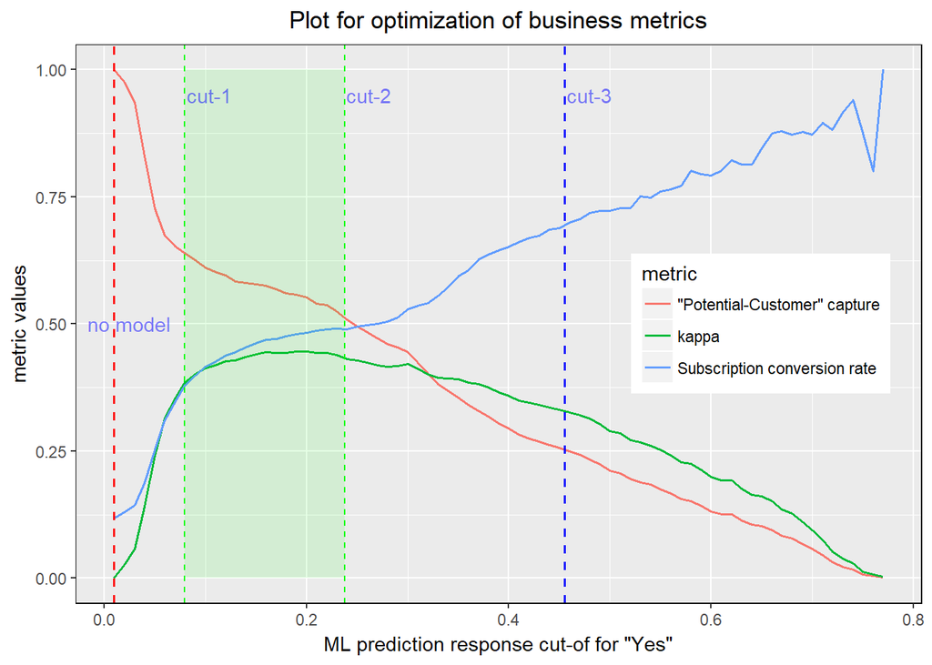

```r
show_plot
```

The x-axis shows the cut-off on prediction response of GBM algoritm, beyond which it is identified as “yes” i.e., customer who subscribed.

Red line shows the chance of capturing the customer that could potentially subscribe. From business perspective higher number is desired with reasonable effort. (In confusion matrix we identified this metric as Specificity)

With this understanding, we can make few business case scenarios. For example:

This concludes the analysis and developing the business case for this data.

# 10 Final Check with Validation Data

It is quite possible that when tuning the model with the test data with many iterations, the model get biased. So to be extra sure, we run the model on validation data which the model never saw.

## 10.1 (technical) R Code

The code creates the prediction response on the Valiation data. Rest of the code is nearly the same as use earlier.

```r
# create prediction vector response for the validation set based
# on the same gbm model fit
pred_gbm <-predict.gbm(gbm_fit, newdata=irvn_gbm[idx==3,],
                        n.trees=gbm.perf(gbm_fit, plot=FALSE), type="response")
```

```
## Using OOB method...
```

```r
ii_min <- as.integer(min(pred_gbm*100))+1
ii_max <- as.integer(max(pred_gbm*100))-1
m_data <-matrix(, nrow = 3, ncol = ii_max-ii_min)
for (ii in ii_min:(ii_max-1)){
  cf<-table(ifelse(pred_gbm > ii/100,"yes","no"), yirvn_vl)
  kappa <- kp(ifelse(pred_gbm > ii/100,"yes","no"), yirvn_vl)
  spec <- cf[2,2]/(cf[1,2]+cf[2,2])
  npred <- cf[2,2]/(cf[2,1]+cf[2,2])
  m_data[1,ii-ii_min+1] <- kappa
  m_data[2,ii-ii_min+1] <- spec
  m_data[3,ii-ii_min+1] <- npred
}
#m_data
row.names(m_data) <- c("kappa", "\"Potential-Customer\" capture", "Subscription conversion rate")
#c("kappa", "specificity", "negPredValue")
colnames(m_data) <- (ii_min:(ii_max-1)-ii_min+1)/100
library(reshape)
df_melted <- melt(m_data)
colnames(df_melted) <- c("metric","predicted_probability", "value")
library(ggplot2)
obj_plot <- ggplot(df_melted, aes(x = predicted_probability, y = value)) +
  geom_line(aes(color = metric, group = metric)) +
  xlab("ML prediction response cut-of for \"Yes\"") + ylab("metric values") +
  theme(panel.border = element_rect(colour = "black", fill=NA, size=0.5)) +
  geom_vline(xintercept=0.08, linetype="dashed", size=0.7, colour="green") +
  geom_vline(xintercept=0.238, linetype="dashed", size=0.7, colour="green") +
  geom_vline(xintercept=0.455, linetype="dashed", size=0.7, colour="blue") +
  theme(legend.position = c(0.81, 0.5)) +
  #legendBackground: c(fill, lineSize, lineType, lineColor)
  annotate("rect", xmin=0.08, xmax=0.238, ymin=0., ymax=1.0, alpha=.1, fill="green") +
  ggtitle("Plot for optimization of business metrics") +
  theme(plot.title = element_text(hjust = 0.5)) +
  geom_vline(xintercept=0.01, linetype="dashed", size=0.7, colour="red") +
  annotate("text", label="no model", x=0.025, y=0.5, colour="blue", alpha=.5) +
  annotate("text", label="cut-1", x=0.104, y=0.95, colour="blue", alpha=.5) +
  annotate("text", label="cut-2", x=0.262, y=0.95, colour="blue", alpha=.5) +
  annotate("text", label="cut-3", x=0.48, y=0.95, colour="blue", alpha=.5)
```

Following graph show the graph

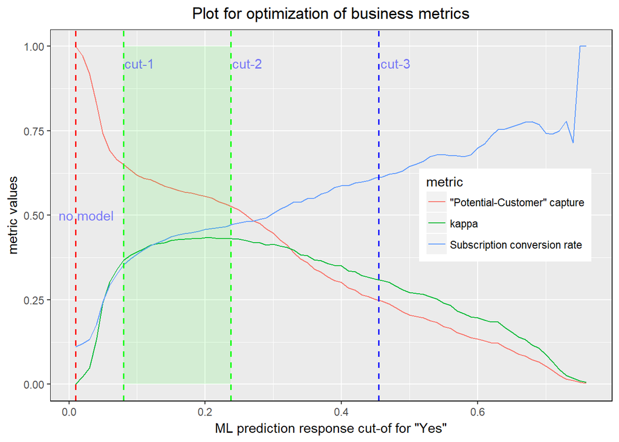

```r
obj_plot
```

# 11 misc

## 11.1 Batch processing in R/Rstudio

In MS Windows do the following:

1. go to command window
2. Rmd file should be converted into R with following command:
   - Rscript -e “library(knitr); purl(‘c:/ds_local/scratch/<file_name.Rmd>’)”
3. The R file is run with following command:
   - R CMD BATCH –slave –no-restore –no-save “<file_name.R>”

## 11.2 This file path:

```
* location 1
```

# 12 Appendix I - Acknowledgements on Datasource

The dataset is available from [UC Irvine site](http://www.dxbydt.com/wp-content/uploads/2017/04/bank-marketing.txt).

I firstly read the article in [Data Science Central](http://www.datasciencecentral.com/profiles/blogs/decision-trees-classification-interpretation-using-scikit-learn) which [refered to the blog](http://www.dxbydt.com/decision-trees-classification-interpretation-using-scikit-learn/)

I am very thankful to UC Irvine for the dataset. Data Science Central on twitter feed has provided great materials for learning data science for which I am ever grateful. Also thanks to Jitesh Shah’s article for the dataset link.

# 13 Appendix II - Data Dictionary

The predictor (same as feature) variables are divided into Customer data, Campaign related attributes and social/economic indicators.

## 13.1 Customer data:

1. *age* (numeric)
2. *job* : type of job (categorical: “admin.”, “blue-collar”, “entrepreneur”, “housemaid”, “management”, “retired”, “self-employed”, “services”, “student”, “technician”, “unemployed”, “unknown”)
3. *marital* : marital status (categorical: “divorced”, “married”, “single”, “unknown”; note: “divorced” means divorced or widowed)
4. *education* (categorical: “basic.4y”, “basic.6y”, “basic.9y”, “high.school”, “illiterate”, “professional.course”, “university.degree”, “unknown”)
5. *default*: has credit in default? (categorical: “no”, “yes”, “unknown”)
6. *housing*: has housing loan? (categorical: “no”, “yes”, “unknown”)
7. *loan*: has personal loan? (categorical: “no”, “yes”, “unknown”)

## 13.2 Campaign attributes

Attributes related to the last touchpoint for the current campaign:

8. *contact*: contact communication type (categorical: “cellular”, “telephone”)
9. *month*: last contact month of year (categorical: “jan”, “feb”, “mar”, …, “nov”, “dec”)
10. *day_of_week*: last contact day of the week (categorical: “mon”, “tue”, “wed”, “thu”, “fri”)
11. *duration*: last contact duration, in seconds (numeric). Important note: this attribute highly affects the output target (e.g., if duration=0 then y=“no”). Yet, the duration is not known before a call is undertaken. Also, after the end of the call, y is obviously known. Thus, this input should only be included for benchmark purposes and should be discarded if the intention is to have a realistic predictive model.

## 13.3 Other attributes:

12. *campaign*: number of contacts performed during this campaign and for this client (numeric, includes last contact)
13. *pdays*: number of days that passed by after the client was last contacted from a previous campaign (numeric; 999 means client was not previously contacted)
14. *previous*: number of contacts performed before this campaign and for this client (numeric)
15. *poutcome*: outcome of the previous marketing campaign (categorical: “failure”, “nonexistent”, “success”)

## 13.4 Social and economic context attributes:

16. *emp.var.rate*: employment variation rate - quarterly indicator (numeric)
17. *cons.price.idx*: consumer price index - monthly indicator (numeric)
18. *cons.conf.idx*: consumer confidence index - monthly indicator (numeric)
19. *euribor3m*: euribor 3 month rate - daily indicator (numeric)
20. *nr.employed*: number of employees - quarterly indicator (numeric)

## 13.5 Target Variable

21. *y* - did the customer subscribe to the product pitched? (binary: “yes”, “no”)

## 13.6 Missing Attribute Values

There are several missing values in some categorical attributes, all coded with the “unknown” label. These missing values can be treated as a possible class label or deletion or imputation techniques can be used on them.